# Chapter 1: Foundations

Shravan Vasishth (vasishth.github.io)

June 2025

# Textbook

Introduction to Bayesian Data Analysis for Cognitive Science

Nicenboim, Schad, Vasishth

- Online version: https://bruno.nicenboim.me/bayescogsci/
- Source code: https://github.com/bnicenboim/bayescogsci
- Physical book: [here](https://www.routledge.com/Introduction-to-Bayesian-Data-Analysis-for-Cognitive-Science/Nicenboim-Schad-Vasishth/p/book/9780367359331)

**Be sure to read the textbook’s chapter 1 in addition to watching this lecture**.

# Introduction: Motivation for this lecture

- Whenever we collect data, an implicit assumption is that the data are being generated from a **random variable**.
- Understanding the basic properties of random variables is of key importance when learning statistical modeling.
- The ideas and concepts in this lecture are often not taught in statistics courses in linguistics and psychology.
- The commonly used cookbook approach to teaching statistics leads to all kinds of misunderstandings that have a snowball effect and are a big part of the cause for the replication crisis and other problems in inference that we see so often in empirical work in linguistics and psychology.

It only takes about a day to understand these materials, but the content here will positively impact your ability to carry out statistical modeling and data analysis.

# Discrete random variables

A random variable $X$ is a function $X : \Omega \rightarrow \mathbb{R}$ that associates to each **outcome** $\omega \in \Omega$ exactly one number $X(\omega) = x$.

$S_X$ is all the $x$’s (all the possible values of X, the **support of X**). I.e., $x \in S_X$.

## An example of a discrete RV

An example of a discrete random variable: keep tossing a coin again and again until you get a Heads.

- $X: \omega \rightarrow x$
- $\omega$: H, TH, TTH,(infinite)
- $X(H)=1, X(TH)=2, X(TTH)=3$,
- $x=1,2,\dots; x \in S_X$

A second example of a discrete random variable: tossing a coin once.

- $X: \omega \rightarrow x$
- $\omega$: H, T
- $X(T)=0, X(H)=1$
- $x=0,1; x \in S_X$

### The probability mass function (PMF)

Every discrete (continuous) random variable X has associated with it a **probability mass (density) function (PMF, PDF)**.

- PMF is used for discrete distributions and PDF for continuous.
- (Some books use PDF for both discrete and continuous distributions.)

Thinking just about discrete random variables for now:

$$\begin{equation}
p_X : S_X \rightarrow [0, 1]
\end{equation}$$

defined by

$$\begin{equation}
p_X(x) = \hbox{Prob}(X(\omega) = x), x \in S_X
\end{equation}$$

Example of a PMF: a random variable $X$ representing tossing a coin once.

- In the case of a fair coin, $x$ can be $0$ or $1$, and the probability of each possible event (each event is a subset of the set of possible outcomes) is $0.5$.
- Formally: $p_X(x) = \hbox{Prob}(X(\omega) = x), x \in S_X$
- The probability mass function defines the probability of each event: $p_X(0) = p_X(1) =0.5$.

### The cumulative distribution function (CDF)

The (CDF) $F(X\leq x)$ gives the cumulative probability of observing all the events $X\leq x$.

$$\begin{equation}
\begin{split}
F(x=1) & = \hbox{Prob}(X \leq 1)\\
& = \sum_{x=0}^{1} p_X(x) \\
& = p_X(x=0) + p_X(x=1) \\
& = 1
\end{split}
\end{equation}$$

$$\begin{equation}
\begin{split}
F(x=0) & = \hbox{Prob}(X \leq 0)\\
& = \sum_{x=0}^{0} p_X(x)\\
& = p_X(x=0) \\
& = 0.5
\end{split}
\end{equation}$$

Do 10 coin-tossing experiments, each with one trial. The probability (which I call $\theta$ below) of heads 0.5:

```r
extraDistr::rbern(n = 10, prob = 0.5)
```

```
##  [1] 0 0 1 1 1 0 1 0 0 1
```

The probability mass function: Bernoulli

$$p_X(x)= \theta^x
(1-\theta)^{(1-x)}$$

where x can have values 0, 1.

What’s the probability of a tails/heads? The d-family of functions:

```r
extraDistr::dbern(0, prob = 0.5)
```

```
## [1] 0.5
```

```r
extraDistr::dbern(1, prob = 0.5)
```

```
## [1] 0.5
```

Notice that these probabilities sum to 1.

The cumulative probability distribution function: the p-family of functions:

$$F(x=1) = Prob(X \leq 1) = \sum_{x=0}^{1}
p_X(x) = 1$$

```r
extraDistr::pbern(1, prob = 0.5)
```

```
## [1] 1
```

$$F(x=0) = Prob(X \leq 0) = \sum_{x=0}^{0}
p_X(x) = 0.5$$

```r
extraDistr::pbern(0, prob = 0.5)
```

```
## [1] 0.5
```

## Another example of a discrete random variable: The binomial

- Consider carrying out a single experiment where you toss a coin 10 times (the number of trials, `size` in R).
- When the number of trials (size) is 1, we have a Bernoulli; when we have size greater than 1, we have a Binomial.

$$\theta^{x}(1-\theta)^{1-x}$$
where
$$S_X=\{0,1\}$$

**Binomial PMF**

$${n \choose x}
\theta^{x}(1-\theta)^{n-x}$$

where
$$S_X=\{0,1,\dots,n\}$$

- $n$ is the number of times the coin was tossed (the number of trials; size in R).
- ${n \choose x}$ is the number of ways that you can get $x$ successes in $n$ trials.

```r
choose(10, 2)
```

```
## [1] 45
```

- $\theta$ is the probability of success in $n$ trials.

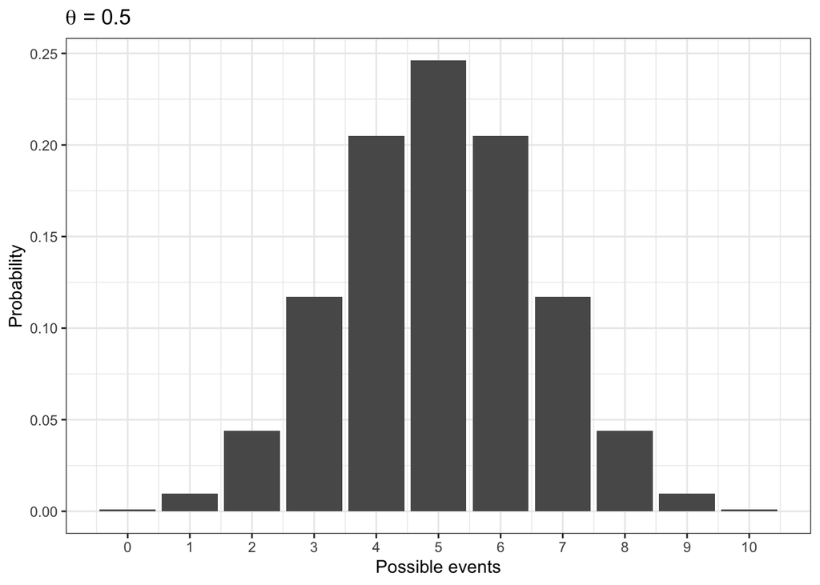

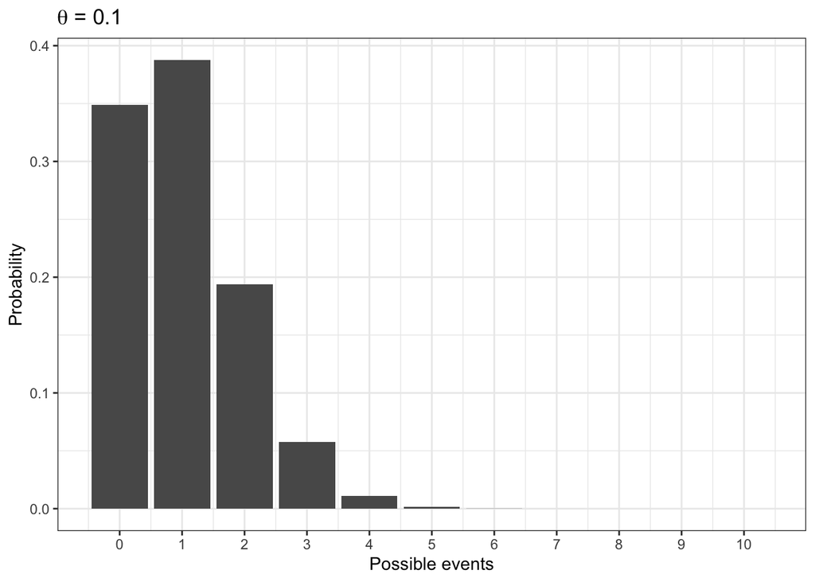

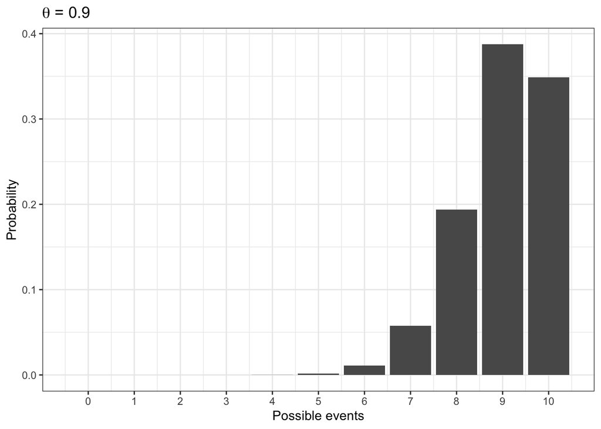

## Four critical R functions for the binomial RV

**1. Generate random data: rbinom**

- n: number of experiments done (**Note**: in the binomial pdf, n stands for the number of trials). In R, n is called the number of observations.
- size: the number of times the coin was tossed in each experiment (the number of trials)

Example: 10 separate experiments, each with 1 trial:

```r
rbinom(n = 10, size = 1, prob = 0.5)
```

```
##  [1] 1 0 0 1 1 0 1 1 0 1
```

```r
## equivalent to: rbern(10,0.5)
```

Example: 10 separate experiments, each with 10 trials:

```r
rbinom(n = 10, size = 10, prob = 0.5)
```

```
##  [1] 6 4 1 9 7 3 3 7 4 9
```

**2. Compute probabilities of particular events (0,1,…,10 successes when n=10): dbinom**

```r
probs <- round(dbinom(0:10, size = 10,
                      prob = 0.5), 3)
x <- 0:10
```

```
##     x probs
## 1   0 0.001
## 2   1 0.010
## 3   2 0.044
## 4   3 0.117
## 5   4 0.205
## 6   5 0.246
## 7   6 0.205
## 8   7 0.117
## 9   8 0.044
## 10  9 0.010
## 11 10 0.001
```

**3. Compute cumulative probabilities: pbinom**

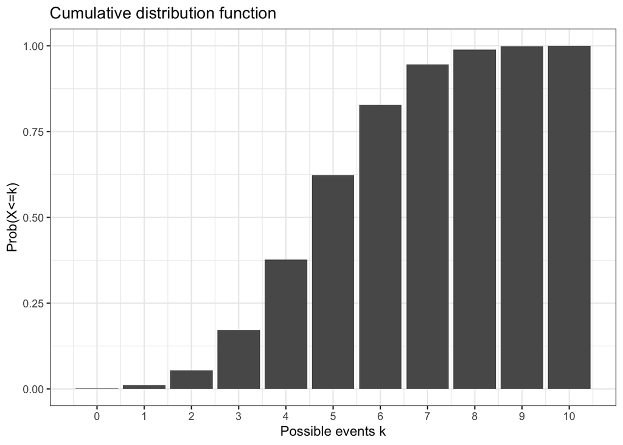

**4. Compute quantiles using the inverse of the CDF: qbinom**

```r
probs <- pbinom(0:10, size = 10, prob = 0.5)
qbinom(probs, size = 10, prob = 0.5)
```

```
##  [1]  0  1  2  3  4  5  6  7  8  9 10
```

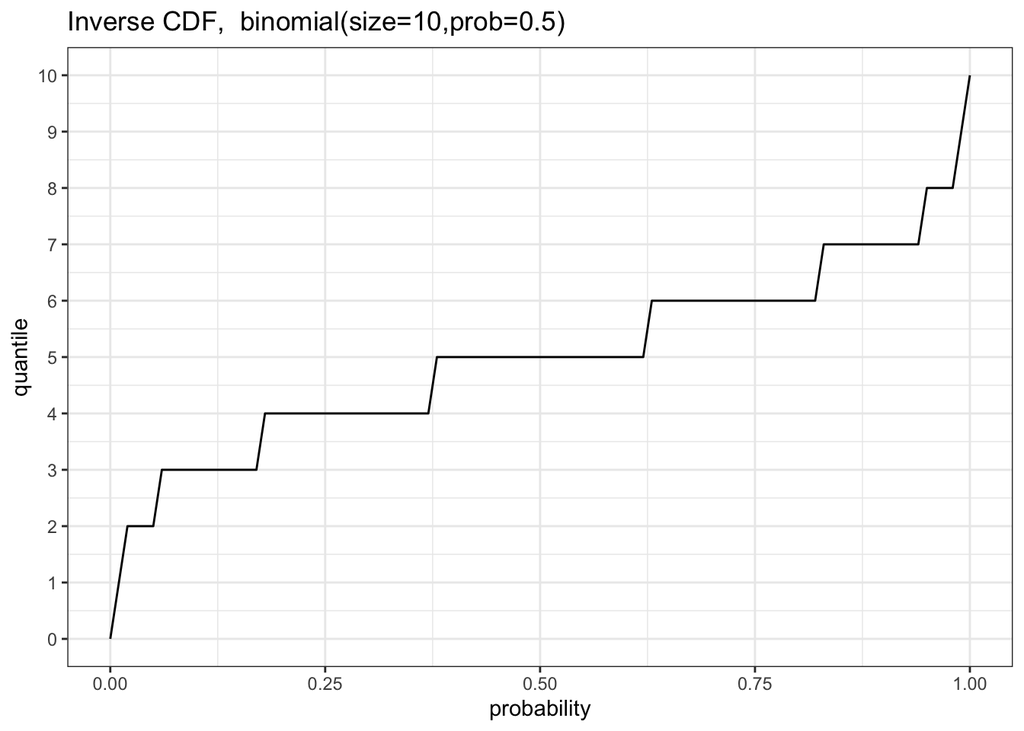

These four functions are the d-p-q-r family of functions, and are available for all the distributions available in R (e.g., Poisson, geometric, normal, beta, uniform, gamma, exponential, Cauchy, etc.).

# Continuous random variables

In coin tosses, H and T are discrete possible outcomes.

- By contrast, variables like reading times range from 0 milliseconds up–these are **continuous variables**.
- Continuous random variables have a probability **density** function (PDF) $f(\cdot)$ associated with them. (cf. PMF in discrete RVs)
- The expression

$$\begin{equation}
X \sim f(\cdot)
\end{equation}$$

means that the random variable $X$ is assumed to have PDF $f(\cdot)$.

For example, if we say that $X\sim Normal(\mu,\sigma)$, we are assuming that the PDF is

$$\begin{equation}
f(x\mid \mu, \sigma)= \frac{1}{\sqrt{2\pi \sigma^2}}
\exp\left[-\frac{(x-\mu)^2}{2\sigma^2}\right]
\end{equation}$$

where $-\infty<x<+\infty$

We can **truncate** the normal distribution such that $S_X$ is bounded between some lower bound and/or upper bound–this comes later.

## The normal random variable

The PDF below is associated with the normal distribution that you are probably familiar with:

$$\begin{equation}
f(x\mid \mu, \sigma)= \frac{1}{\sqrt{2\pi \sigma^2}}
\exp\left[-\frac{(x-\mu)^2}{2\sigma^2}\right]
\end{equation}$$

where $-\infty<x<+\infty$.

- The support of $X$, i.e., the elements of $S_X$, has values ranging from $-\infty$ to $+\infty$
- $\mu$ is the location parameter (here, mean)
- $\sigma$ is the scale parameter (here, standard deviation)

In the discrete RV case, we could compute the probability of a event occurring:

```r
extraDistr::dbern(x = 1, prob = 0.5)
```

```
## [1] 0.5
```

```r
dbinom(x = 2, size = 10, prob = 0.5)
```

```
## [1] 0.04394531
```

- In a continuous distribution, probability is defined as the **area under the curve**.
- As a consequence, for any particular **point** value $x$, where $X\sim Normal(\mu,\sigma)$, it is always the case that $\hbox{Prob}(X=x) = 0$.
- In any continuous distribution, we can compute probabilities like $\hbox{Prob}(x_1<X<x_2) = ?$, where $x_1<x_2$, by summing up the **area under the curve**.
- To compute probabilities like $\hbox{Prob}(x_1<X<x_2) = ?$, we need the cumulative distribution function.

The cumulative distribution function (CDF) is

$$\begin{equation}
P(X<u) = F(X<u) =\int_{-\infty}^{u} f(x)\, dx
\end{equation}$$

- The integral sign $\int$ is just the summation symbol in continuous space.
- Recall the summation in the CDF of the Bernoulli!

## The standard normal distribution

In the $Normal(\mu=0,\sigma=1)$,

- Prob$(-1<X<+1) = 0.68$
- Prob$(-2<X<+2) = 0.95$
- Prob$(-3<X<+3) = 0.997$

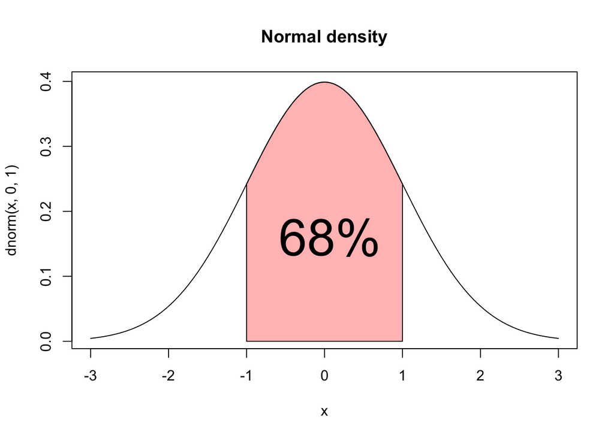

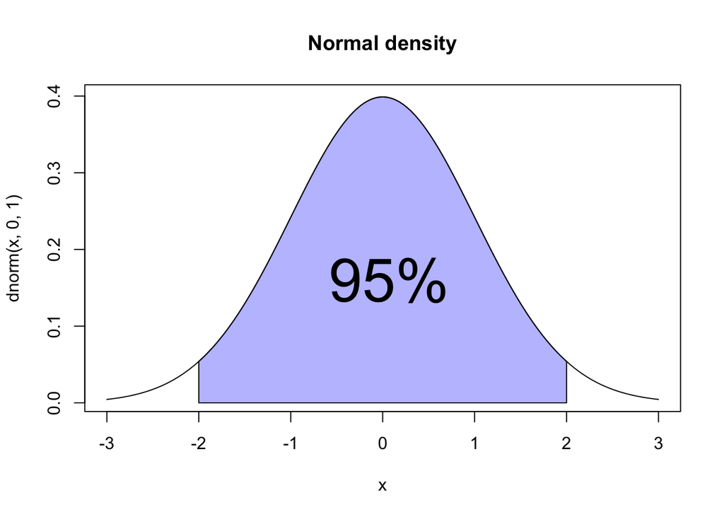

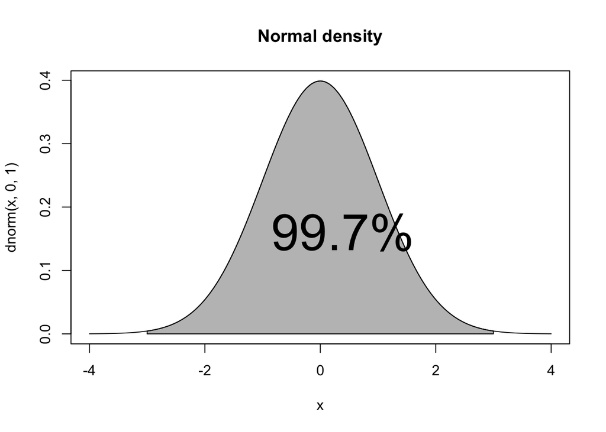

More generally, for any $Normal(\mu,\sigma)$,

- Prob$(-1\times \sigma <X<+1\times \sigma) = 0.68$
- Prob$(-2\times \sigma <X<+2\times \sigma) = 0.95$
- Prob$(-3\times \sigma<X<+3\times \sigma) = 0.997$

## The normalizing constant and the kernel

The PDF of the normal again:

$$\begin{equation}
f(x\mid \mu, \sigma)= \frac{1}{\sqrt{2\pi \sigma^2}}
\exp\left[-\frac{(x-\mu)^2}{2\sigma^2}\right]
\end{equation}$$

This part of $f(x\mid \mu,\sigma)$ (call it $g(x)$) is the ``kernel’’ of the normal PDF:

$$\begin{equation}
g(x\mid \mu, \sigma) = \exp\left[-\frac{(x-\mu)^2}{2 \sigma^2}\right]
\end{equation}$$

For the above function, the area under the curve doesn’t sum to 1:

Sum up the area under the curve $\int g(x)\, dx$:

```r
g <- function(x, mu = 0, sigma = 1) {
  exp((-(x - mu)^2 / (2 * (sigma^2))))
}

integrate(g, lower = -Inf, upper = +Inf)$value
```

```
## [1] 2.506628
```

The shape doesn’t change of course:

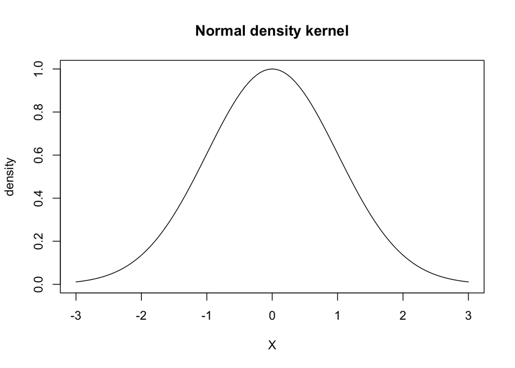

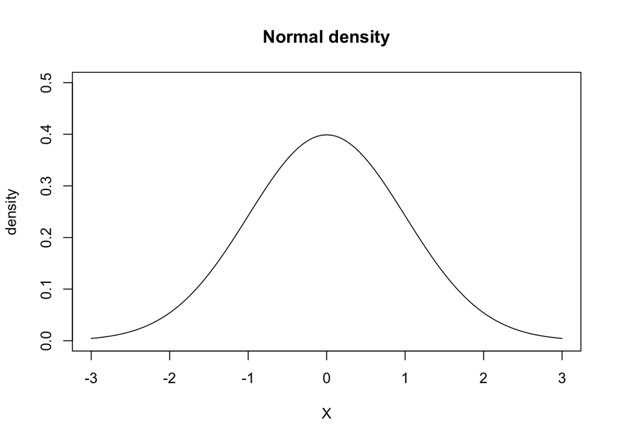

In simple examples like the one shown here, given the kernel of some PDF like $g(x)$, we can figure out the normalizing constant by solving for $k$ in:

$$\begin{equation}
k \int g(x)\, dx = 1
\end{equation}$$

Solving for $k$ just amounts to computing:

$$\begin{equation}
k = \frac{1}{\int g(x)\, dx}
\end{equation}$$

So, in our example above,

```r
(k<-1/integrate(g, lower = -Inf, upper = +Inf)$value)
```

```
## [1] 0.3989423
```

The above number is just $\frac{1}{\sqrt{2 \pi \sigma^2}}$, where $\sigma=1$:

```r
1/(sqrt(2*pi*1))
```

```
## [1] 0.3989423
```

Once we include the normalizing constant, the area under the curve in $g(x)$ sums to 1:

```r
k * integrate(g, lower = -Inf, upper = +Inf)$value
```

```
## [1] 1
```

We will see the practical implication of this when we move on to chapter 2 of the textbook.

## The d-p-q-r functions for the normal distribution

In the continuous case, we also have this family of d-p-q-r functions. In the normal distribution:

**1. Generate random data using rnorm**

```r
round(rnorm(5, mean = 0, sd = 1),3)
```

```
## [1] -0.740 -0.844 -1.165 -1.840  0.976
```

For the standard normal, mean=0, and sd=1 can be omitted (these are the default values in R).

```r
round(rnorm(5),3)
```

```
## [1]  0.537  1.081  1.082 -1.117  0.787
```

**2. Compute probabilities using CDF: pnorm**

Some examples of usage:

- $\hbox{Prob}(X<2)$ (e.g., in $X\sim Normal(0,1)$)

```r
pnorm(2)
```

```
## [1] 0.9772499
```

- $\hbox{Prob}(X>2)$ (e.g., in $X\sim Normal(0,1)$)

```r
pnorm(2, lower.tail = FALSE)
```

```
## [1] 0.02275013
```

**3. Compute quantiles: qnorm**

```r
qnorm(0.9772499)
```

```
## [1] 2.000001
```

**4. Compute the probability density: dnorm**

```r
dnorm(2)
```

```
## [1] 0.05399097
```

**Note**: In the continuous case, this is a **density**, the value $f(x)$, not a probability. Cf. the discrete examples dbern and dbinom, which give probabilities of a point value $x$.

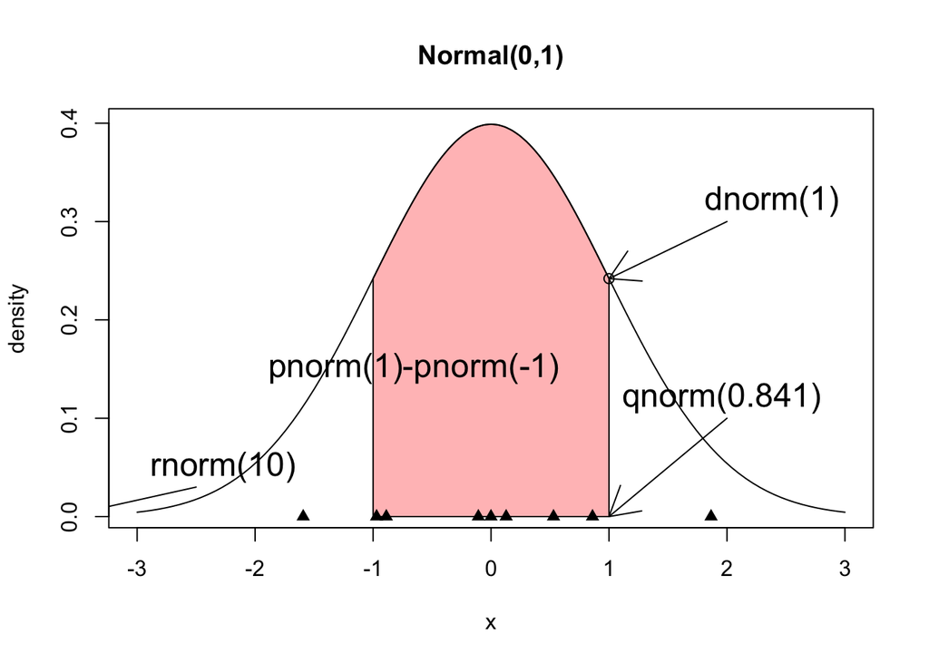

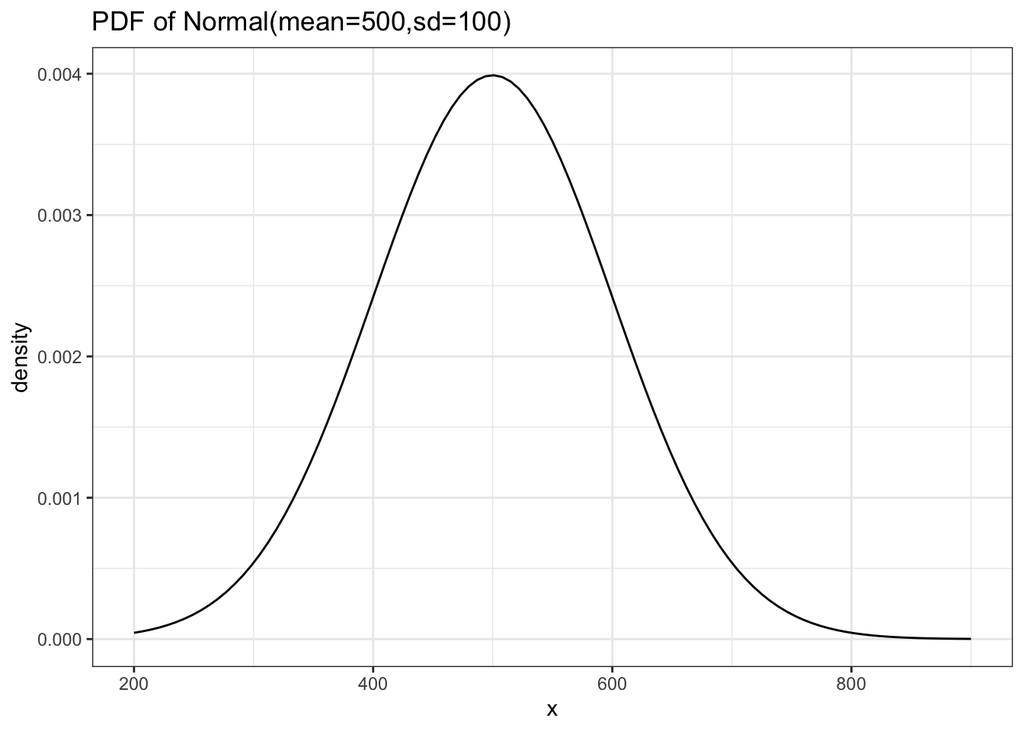

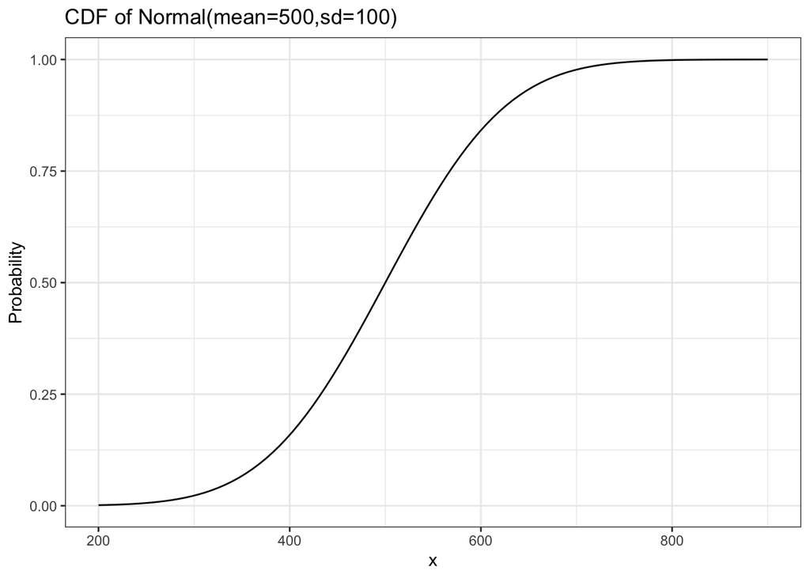

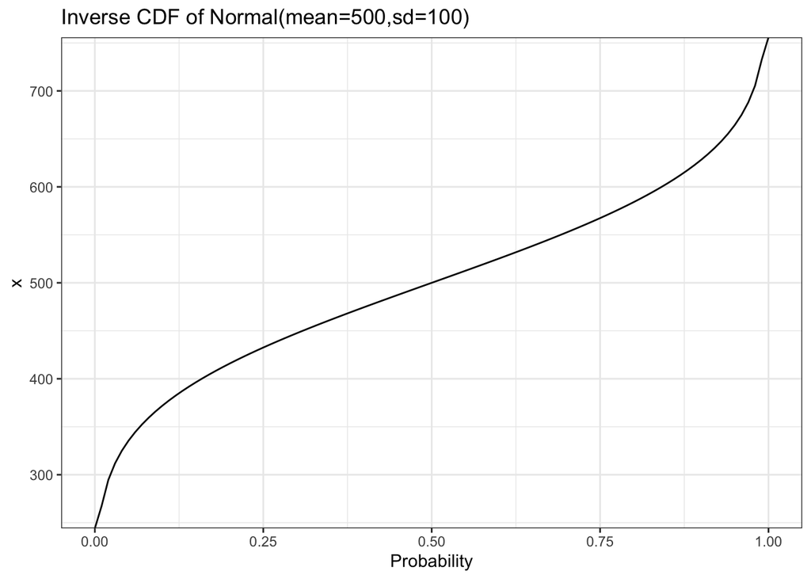

# The likelihood function (Binomial)

The **likelihood function** refers to the PMF $p(k|n,\theta)$, treated as a function of $\theta$.

For example, suppose that we record $n=10$ trials, and observe $k=7$ successes. The likelihood function is:

$$\begin{equation}
\mathcal{L}(\theta|k=7,n=10)=
\binom{10}{7} \theta^{7} (1-\theta)^{10-7}
\end{equation}$$

If we now plot the likelihood function for all possible values of $\theta$ ranging from $0$ to $1$, we get the plot shown below.

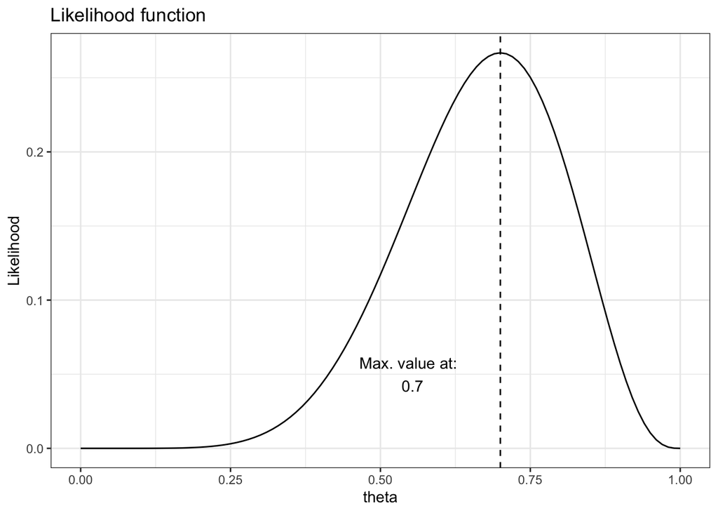

The MLE (**from a particular sample** of data need not invariably give us an accurate estimate of $\theta$.

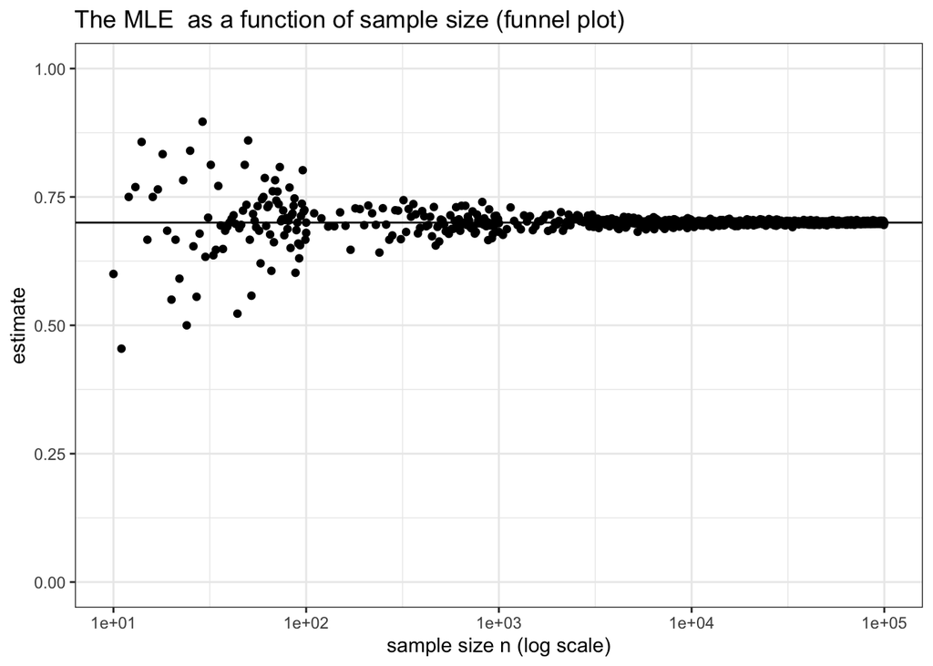

Sample size is key here: as $n\rightarrow \infty$, we approach the true value of the parameter (here, $\theta$).

# The likelihood function (Normal)

$$\begin{equation}
\mathcal{L}(\mu,\sigma|x)=Normal(x,\mu,\sigma)
\end{equation}$$

Below, assume that $\sigma=1$.

```r
## the data:
x<-0
## the likelihood under different values
## of mu:
dnorm(x,mean=0,sd=1)
```

```
## [1] 0.3989423
```

```r
dnorm(x,mean=10,sd=1)
```

```
## [1] 7.694599e-23
```

Assuming that $\sigma=1$, the likelihood function of $\mu$:

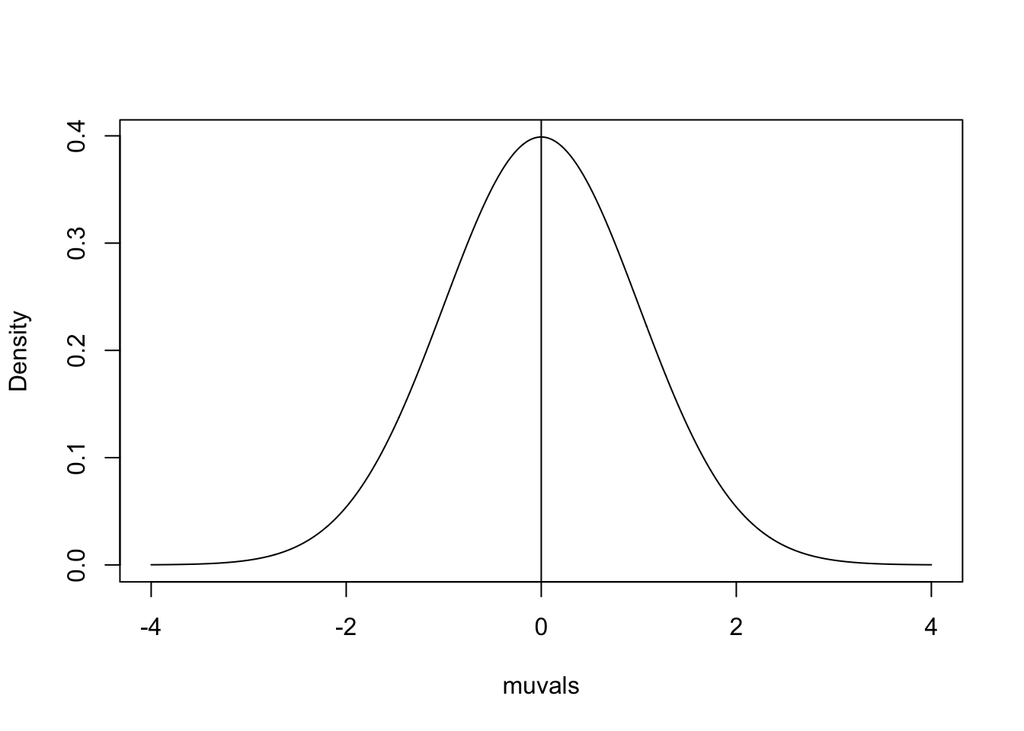

If we have two **independent** data points, the joint likelihood given the data of $\mu$, assuming $\sigma=1$:

```r
x1<-0
x2<-1.5
dnorm(x1,mean=0,sd=1) *
  dnorm(x2,mean=0,sd=1)
```

```
## [1] 0.05167004
```

```r
## log likelihood:
dnorm(x1,mean=0,sd=1,log=TRUE) +
  dnorm(x2,mean=0,sd=1,log=TRUE)
```

```
## [1] -2.962877
```

```r
## more compactly:
x<-c(x1,x2)
sum(dnorm(x,mean=0,sd=1,log=TRUE))
```

```
## [1] -2.962877
```

One practical implication: one can use the log likelihood to compare competing models’ fit:

```r
## Model 1:
sum(dnorm(x,mean=0,sd=1,log=TRUE))
```

```
## [1] -2.962877
```

```r
## Model 2:
sum(dnorm(x,mean=10,sd=1,log=TRUE))
```

```
## [1] -87.96288
```

Model 1 has higher likelihood than Model 2, so we’d prefer to assume that the data are better characterized by Model 1 than 2 (neither may be the true model!).

More generally, for independent and identically distributed data $x=x_1,\dots,x_n$:

$$\begin{equation}
\mathcal{L}(\mu,\sigma|x) = \prod_{i=1}^n Normal(x_i,\mu,\sigma)
\end{equation}$$

or

$$\begin{equation}
\ell (\mu,\sigma|x) = \sum_{i=1}^n log(Normal(x_i,\mu,\sigma))
\end{equation}$$

# The expectation and variance of an RV

Read section 1.4.1 of chapter 1 of the textbook, and (optionally) chapter 2 of the linear modeling lecture notes here:

https://github.com/vasishth/LM

# Bivariate/multivariate distributions

## Discrete bivariate distributions

Data from: Laurinavichyute, A. (2020). Similarity-based interference and faulty encoding accounts of sentence processing. dissertation, University of Potsdam.

X: Likert ratings 1-7.

Y: 0, 1 accuracy responses.

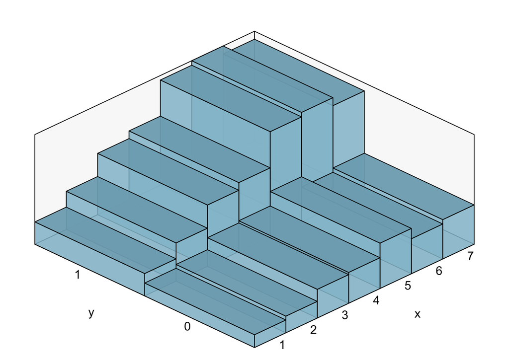

The joint PMF: $p_{X,Y}(x,y)$

For each possible pair of values of X and Y, we have a **joint probability mass function** $p_{X,Y}(x,y)$.

Two useful quantities that we can compute:

### The marginal distributions ($p_{X}$ and $p_Y$)

$$\begin{equation}
p_{X}(x)=\sum_{y\in S_{Y}}p_{X,Y}(x,y).\label{eq-marginal-pmf2}
\end{equation}$$

$$\begin{equation}
p_{Y}(y)=\sum_{x\in S_{X}}p_{X,Y}(x,y).\label{eq-marginal-pmf}
\end{equation}$$

The joint PMF for two random variables X and Y, along with the marginal distributions of X and Y.

|  | $x=1$ | $x=2$ | $x=3$ | $x=4$ | $x=5$ | $x=6$ | $x=7$ | $p(Y)$ |
| --- | --- | --- | --- | --- | --- | --- | --- | --- |
| $y=0$ | $0.018$ | $0.023$ | $0.04$ | $0.043$ | $0.063$ | $0.049$ | $0.055$ | $0.291$ |
| $y=1$ | $0.031$ | $0.053$ | $0.086$ | $0.096$ | $0.147$ | $0.153$ | $0.142$ | $0.709$ |
| $p(X)$ | $0.049$ | $0.077$ | $0.126$ | $0.139$ | $0.21$ | $0.202$ | $0.197$ |  |

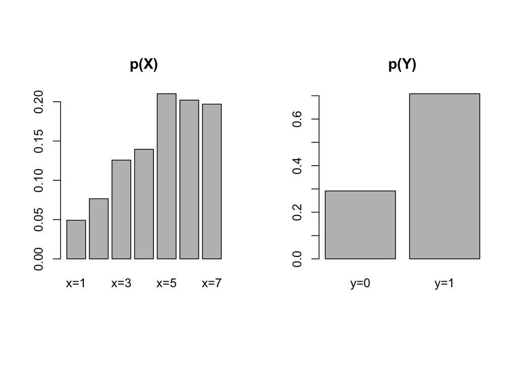

### The conditional distributions ($p_{X|Y}$ and $p_{Y|X}$)

$$\begin{equation}
p_{X\mid Y}(x\mid y) = \frac{p_{X,Y}(x,y)}{p_Y(y)}
\end{equation}$$

and

$$\begin{equation}
p_{Y\mid X}(y\mid x) = \frac{p_{X,Y}(x,y)}{p_X(x)}
\end{equation}$$

Let’s do the calculation for $p_{X\mid Y}(x\mid y=0)$.

The joint PMF for two random variables X and Y, along with the marginal distributions of X and Y.

|  | $x=1$ | $x=2$ | $x=3$ | $x=4$ | $x=5$ | $x=6$ | $x=7$ | $p(Y)$ |
| --- | --- | --- | --- | --- | --- | --- | --- | --- |
| $y=0$ | $0.018$ | $0.023$ | $0.04$ | $0.043$ | $0.063$ | $0.049$ | $0.055$ | $0.291$ |
| $y=1$ | $0.031$ | $0.053$ | $0.086$ | $0.096$ | $0.147$ | $0.153$ | $0.142$ | $0.709$ |
| $p(X)$ | $0.049$ | $0.077$ | $0.126$ | $0.139$ | $0.21$ | $0.202$ | $0.197$ |  |

$$\begin{equation}
\begin{split}
p_{X\mid Y} (1\mid 0) =& \frac{p_{X,Y}(1,0)}{p_Y(0)}\\
=& \frac{0.018}{0.291}\\
=& 0.062
\end{split}
\end{equation}$$

As an exercise, figure out the conditional distribution of X given Y, and the conditional distribution of Y given X.

## Continuous bivariate distributions

Next, we turn to continuous bivariate/multivariate distributions.

The variance-covariance matrix:

$$\begin{equation}\label{eq:covmatfoundations}
\Sigma
=
\begin{pmatrix}
\sigma _{X}^2 & \rho_{XY}\sigma _{X}\sigma _{Y}\\
\rho_{XY}\sigma _{X}\sigma _{Y} & \sigma _{Y}^2\\
\end{pmatrix}
\end{equation}$$

The off-diagonals of this matrix contain the covariance between $X$ and $Y$:

$$Cov(X,Y) = \rho_{XY}\sigma _{X}\sigma
_{Y}$$

The joint distribution of $X$ and $Y$ is defined as follows:

$$\begin{equation}\label{eq:jointpriordistfoundations}
\begin{pmatrix}
X \\
Y \\
\end{pmatrix}
\sim
\mathcal{N}_2 \left(
\begin{pmatrix}
0 \\
0 \\
\end{pmatrix},
\Sigma
\right)
\end{equation}$$

The joint PDF has the property that the volume under the surface sums to 1.

Formally, we would write the volume under the surface as a double integral: we are summing up the volume under the surface for both $X$ and $Y$ (hence the two integrals).

$$\begin{equation}
\iint_{S_{X,Y}} f_{X,Y}(x,y)\, dx dy = 1
\end{equation}$$

Here, the terms $dx$ and $dy$ express the fact that we are computing the volume under the surface along the $X$ axis and the $Y$ axis.

The joint CDF would be written as follows. The equation below gives us the probability of observing a value like $(u,v)$ or some value smaller than that (i.e., some $(u',v')$, such that $u'<u$ and $v'<v$).

$$\begin{equation}
\begin{split}
F_{X,Y}(u,v) =& \hbox{Prob}(X<u,Y<v)\\
=& \int_{-\infty}^u \int_{-\infty}^v f_{X,Y}(x,y)\, dy
dx \\
~& \hbox{ for } (x,y) \in \mathbb{R}^2\\
\end{split}
\end{equation}$$

Just as in the discrete case, the marginal distributions can be derived by marginalizing out the other random variable:

$$\begin{equation}
f_X(x) = \int_{S_Y} f_{X,Y}(x,y)\, dy \quad f_Y(y) = \int_{S_X}
f_{X,Y}(x,y)\, dx
\end{equation}$$

Here, $S_X$ and $S_Y$ are the respective supports.

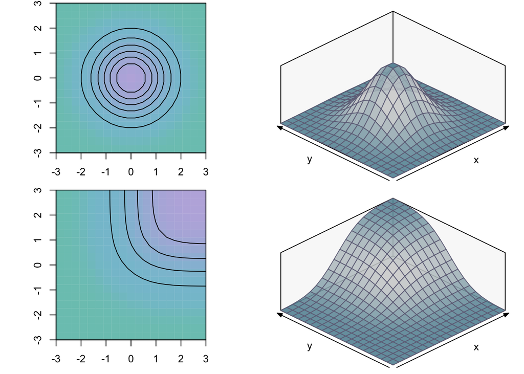

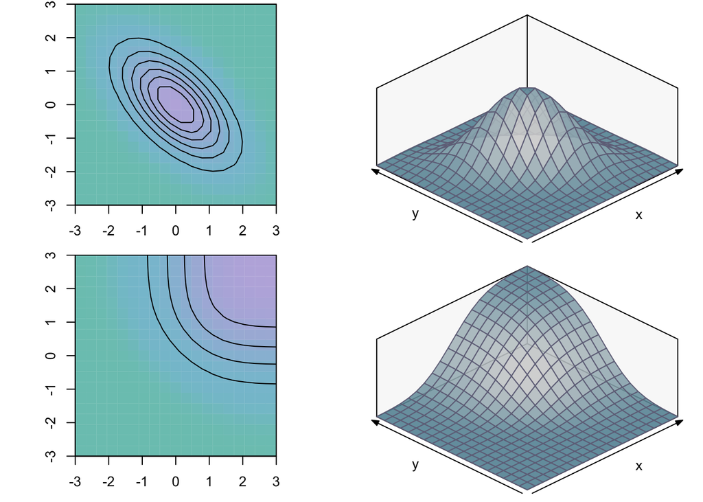

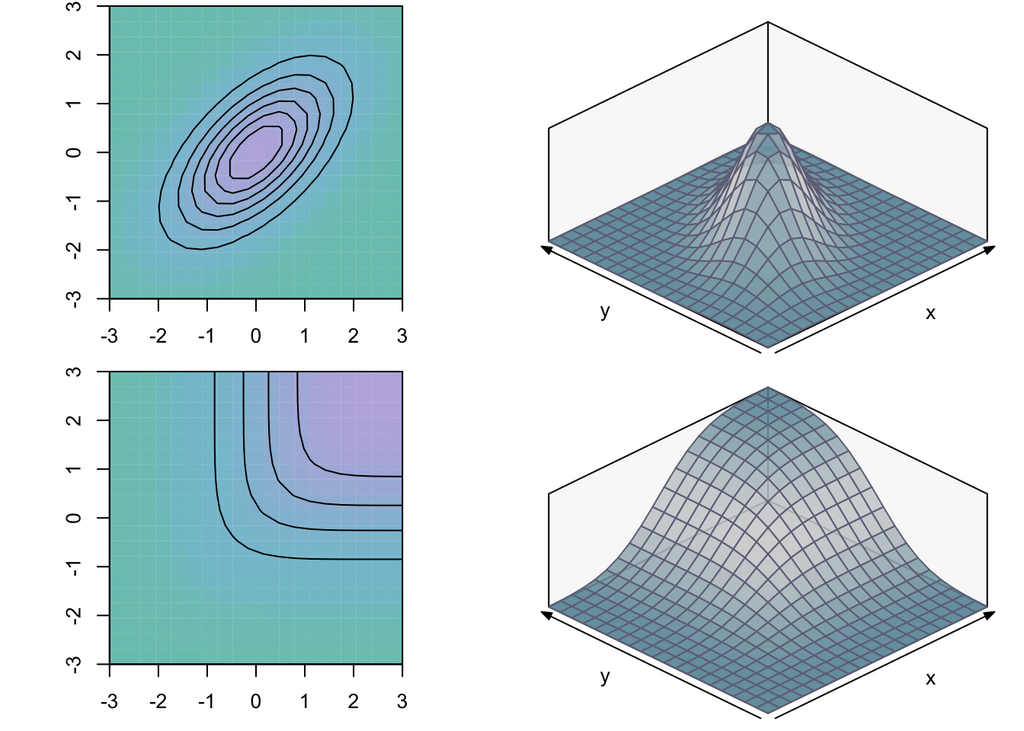

## Generate simulated bivariate (multivariate) data

```r
## define a variance-covariance matrix:
Sigma <- matrix(c(5^2, 5 * 10 * 0.6,
                  5 * 10 * 0.6, 10^2),
  byrow = FALSE, ncol = 2
)
## generate data:
u <- MASS::mvrnorm(n = 100, mu = c(0, 0),
                   Sigma = Sigma)
head(u, n = 3)
```

```
##            [,1]        [,2]
## [1,]  -7.002361  -6.3676288
## [2,] -12.280657 -32.1361568
## [3,]   6.121248   0.3552562
```

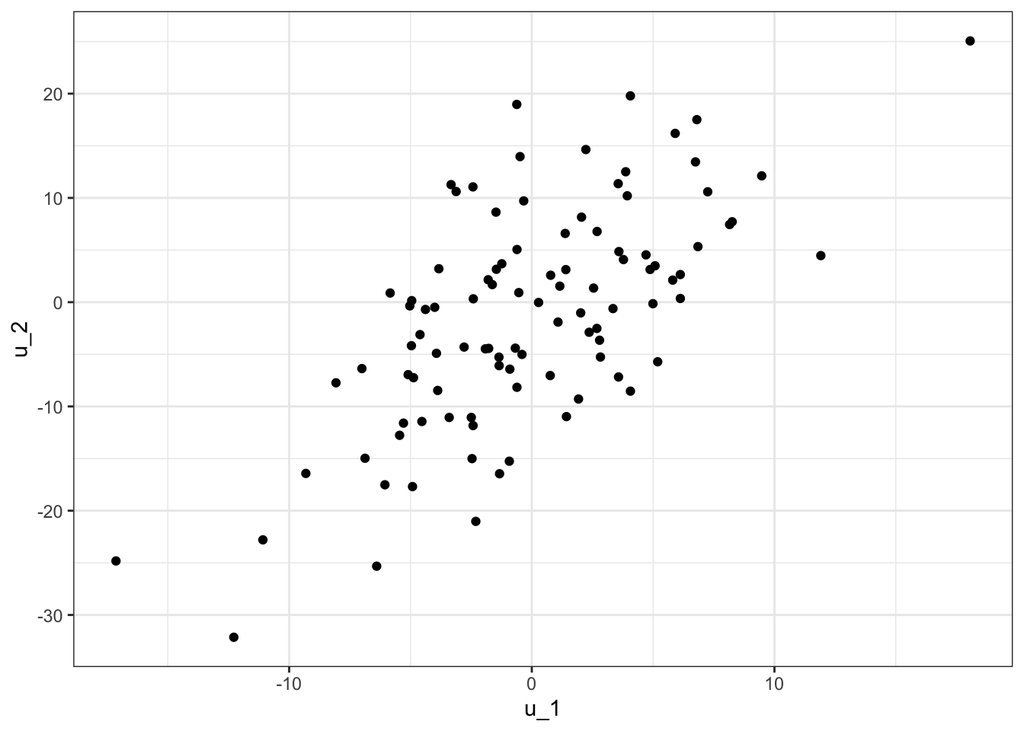

One practical implication: Such bi/multivariate distributions become critically important to understand when we turn to hierarchical (linear mixed) models.